```python
# notes to self
# data1 is data but dropped Booking_ID
# data2 is data1 but adults==0 entries only
# data3 is data1 but children!=0 entries only
# data4 is a copy of data1 but has custom column 'total_nights'
# data5 is data4 but cancellations!=0 entries only
# data6 is data4 but repeat_guests!=0 entries only
# data7 is data4 but special_requests!=0 entries only
# data8 is data4 but special_requests==0 entries only
```

# INN Hotels Project

## Context

A significant number of hotel bookings are called-off due to cancellations or no-shows. The typical reasons for cancellations include change of plans, scheduling conflicts, etc. This is often made easier by the option to do so free of charge or preferably at a low cost which is beneficial to hotel guests but it is a less desirable and possibly revenue-diminishing factor for hotels to deal with. Such losses are particularly high on last-minute cancellations.

The new technologies involving online booking channels have dramatically changed customers’ booking possibilities and behavior. This adds a further dimension to the challenge of how hotels handle cancellations, which are no longer limited to traditional booking and guest characteristics.

The cancellation of bookings impact a hotel on various fronts:

- Loss of resources (revenue) when the hotel cannot resell the room.
- Additional costs of distribution channels by increasing commissions or paying for publicity to help sell these rooms.
- Lowering prices last minute, so the hotel can resell a room, resulting in reducing the profit margin.
- Human resources to make arrangements for the guests.

## Objective

The increasing number of cancellations calls for a Machine Learning based solution that can help in predicting which booking is likely to be canceled. INN Hotels Group has a chain of hotels in Portugal, they are facing problems with the high number of booking cancellations and have reached out to your firm for data-driven solutions. You as a data scientist have to analyze the data provided to find which factors have a high influence on booking cancellations, build a predictive model that can predict which booking is going to be canceled in advance, and help in formulating profitable policies for cancellations and refunds.

## Data Description

The data contains the different attributes of customers' booking details. The detailed data dictionary is given below.

**Data Dictionary**

- Booking_ID: unique identifier of each booking
- no_of_adults: Number of adults
- no_of_children: Number of Children
- no_of_weekend_nights: Number of weekend nights (Saturday or Sunday) the guest stayed or booked to stay at the hotel
- no_of_week_nights: Number of week nights (Monday to Friday) the guest stayed or booked to stay at the hotel
- type_of_meal_plan: Type of meal plan booked by the customer:
  - Not Selected – No meal plan selected
  - Meal Plan 1 – Breakfast
  - Meal Plan 2 – Half board (breakfast and one other meal)
  - Meal Plan 3 – Full board (breakfast, lunch, and dinner)
- required_car_parking_space: Does the customer require a car parking space? (0 - No, 1- Yes)
- room_type_reserved: Type of room reserved by the customer. The values are ciphered (encoded) by INN Hotels.
- lead_time: Number of days between the date of booking and the arrival date
- arrival_year: Year of arrival date
- arrival_month: Month of arrival date
- arrival_date: Date of the month
- market_segment_type: Market segment designation.
- repeated_guest: Is the customer a repeated guest? (0 - No, 1- Yes)
- no_of_previous_cancellations: Number of previous bookings that were canceled by the customer prior to the current booking
- no_of_previous_bookings_not_canceled: Number of previous bookings not canceled by the customer prior to the current booking
- avg_price_per_room: Average price per day of the reservation; prices of the rooms are dynamic. (in euros)
- no_of_special_requests: Total number of special requests made by the customer (e.g. high floor, view from the room, etc)
- booking_status: Flag indicating if the booking was canceled or not.

## Importing necessary libraries and data

```python
# import necessary libraries
import numpy as np
import pandas as pd
import seaborn as sns
import scipy.stats as stats
import matplotlib.pyplot as plt

import warnings
warnings.filterwarnings("ignore")

from statsmodels.tools.sm_exceptions import ConvergenceWarning
warnings.simplefilter("ignore", ConvergenceWarning)

# Removes the limit for the number of displayed columns
pd.set_option("display.max_columns", None)
# Sets the limit for the number of displayed rows
pd.set_option("display.max_rows", 200)
# setting the precision of floating numbers to 5 decimal points
pd.set_option("display.float_format", lambda x: "%.5f" % x)

# Library to split data
from sklearn.model_selection import train_test_split

# To build model for prediction
import statsmodels.stats.api as sms
from statsmodels.stats.outliers_influence import variance_inflation_factor
import statsmodels.api as sm
from statsmodels.tools.tools import add_constant
from sklearn.tree import DecisionTreeClassifier
from sklearn import tree

# To tune different models
from sklearn.model_selection import GridSearchCV

# To get diferent metric scores
from sklearn.metrics import (
    f1_score,
    accuracy_score,
    recall_score,
    precision_score,
    confusion_matrix,
    make_scorer,
)
```

**Note**: *After running the above cell, kindly restart the notebook kernel and run all cells sequentially from the start again.*

```python
# mount my google drive
from google.colab import drive
drive.mount('/content/drive')

# read the csv file to a data frame
data=pd.read_csv('/content/drive/MyDrive/Python Foundations - GreatLearning/INNHotelsGroup.csv')
```

## Data Overview

- Observations
- Sanity checks

```python
data.head()
# viewing the first 5 rows
```

|  | Booking_ID | no_of_adults | no_of_children | no_of_weekend_nights | no_of_week_nights | type_of_meal_plan | required_car_parking_space | room_type_reserved | lead_time | arrival_year | arrival_month | arrival_date | market_segment_type | repeated_guest | no_of_previous_cancellations | no_of_previous_bookings_not_canceled | avg_price_per_room | no_of_special_requests | booking_status |
| --- | --- | --- | --- | --- | --- | --- | --- | --- | --- | --- | --- | --- | --- | --- | --- | --- | --- | --- | --- |
| 0 | INN00001 | 2 | 0 | 1 | 2 | Meal Plan 1 | 0 | Room_Type 1 | 224 | 2017 | 10 | 2 | Offline | 0 | 0 | 0 | 65.00000 | 0 | Not_Canceled |
| 1 | INN00002 | 2 | 0 | 2 | 3 | Not Selected | 0 | Room_Type 1 | 5 | 2018 | 11 | 6 | Online | 0 | 0 | 0 | 106.68000 | 1 | Not_Canceled |
| 2 | INN00003 | 1 | 0 | 2 | 1 | Meal Plan 1 | 0 | Room_Type 1 | 1 | 2018 | 2 | 28 | Online | 0 | 0 | 0 | 60.00000 | 0 | Canceled |
| 3 | INN00004 | 2 | 0 | 0 | 2 | Meal Plan 1 | 0 | Room_Type 1 | 211 | 2018 | 5 | 20 | Online | 0 | 0 | 0 | 100.00000 | 0 | Canceled |
| 4 | INN00005 | 2 | 0 | 1 | 1 | Not Selected | 0 | Room_Type 1 | 48 | 2018 | 4 | 11 | Online | 0 | 0 | 0 | 94.50000 | 0 | Canceled |

```python
data.tail()
# viewing the last five rows
```

|  | Booking_ID | no_of_adults | no_of_children | no_of_weekend_nights | no_of_week_nights | type_of_meal_plan | required_car_parking_space | room_type_reserved | lead_time | arrival_year | arrival_month | arrival_date | market_segment_type | repeated_guest | no_of_previous_cancellations | no_of_previous_bookings_not_canceled | avg_price_per_room | no_of_special_requests | booking_status |
| --- | --- | --- | --- | --- | --- | --- | --- | --- | --- | --- | --- | --- | --- | --- | --- | --- | --- | --- | --- |
| 36270 | INN36271 | 3 | 0 | 2 | 6 | Meal Plan 1 | 0 | Room_Type 4 | 85 | 2018 | 8 | 3 | Online | 0 | 0 | 0 | 167.80000 | 1 | Not_Canceled |
| 36271 | INN36272 | 2 | 0 | 1 | 3 | Meal Plan 1 | 0 | Room_Type 1 | 228 | 2018 | 10 | 17 | Online | 0 | 0 | 0 | 90.95000 | 2 | Canceled |
| 36272 | INN36273 | 2 | 0 | 2 | 6 | Meal Plan 1 | 0 | Room_Type 1 | 148 | 2018 | 7 | 1 | Online | 0 | 0 | 0 | 98.39000 | 2 | Not_Canceled |
| 36273 | INN36274 | 2 | 0 | 0 | 3 | Not Selected | 0 | Room_Type 1 | 63 | 2018 | 4 | 21 | Online | 0 | 0 | 0 | 94.50000 | 0 | Canceled |
| 36274 | INN36275 | 2 | 0 | 1 | 2 | Meal Plan 1 | 0 | Room_Type 1 | 207 | 2018 | 12 | 30 | Offline | 0 | 0 | 0 | 161.67000 | 0 | Not_Canceled |

```python
# viewing the shape of the data
data.shape
```

```
(36275, 19)
```

The data has 19 columns and 36275 rows.

```python
# check for info about the data
data.info()
```

```
<class 'pandas.core.frame.DataFrame'>
RangeIndex: 36275 entries, 0 to 36274
Data columns (total 19 columns):
 #   Column                                Non-Null Count  Dtype
---  ------                                --------------  -----
 0   Booking_ID                            36275 non-null  object
 1   no_of_adults                          36275 non-null  int64
 2   no_of_children                        36275 non-null  int64
 3   no_of_weekend_nights                  36275 non-null  int64
 4   no_of_week_nights                     36275 non-null  int64
 5   type_of_meal_plan                     36275 non-null  object
 6   required_car_parking_space            36275 non-null  int64
 7   room_type_reserved                    36275 non-null  object
 8   lead_time                             36275 non-null  int64
 9   arrival_year                          36275 non-null  int64
 10  arrival_month                         36275 non-null  int64
 11  arrival_date                          36275 non-null  int64
 12  market_segment_type                   36275 non-null  object
 13  repeated_guest                        36275 non-null  int64
 14  no_of_previous_cancellations          36275 non-null  int64
 15  no_of_previous_bookings_not_canceled  36275 non-null  int64
 16  avg_price_per_room                    36275 non-null  float64
 17  no_of_special_requests                36275 non-null  int64
 18  booking_status                        36275 non-null  object
dtypes: float64(1), int64(13), object(5)
memory usage: 5.3+ MB
```

It appears that there are no null values. There may yet still be things like "n/a" or "none" in the object data types. We'll check those later.

```python
# checking for null values
data.isnull().sum()
```

|  | 0 |
| --- | --- |
| Booking_ID | 0 |
| no_of_adults | 0 |
| no_of_children | 0 |
| no_of_weekend_nights | 0 |
| no_of_week_nights | 0 |
| type_of_meal_plan | 0 |
| required_car_parking_space | 0 |
| room_type_reserved | 0 |
| lead_time | 0 |
| arrival_year | 0 |
| arrival_month | 0 |
| arrival_date | 0 |
| market_segment_type | 0 |
| repeated_guest | 0 |
| no_of_previous_cancellations | 0 |
| no_of_previous_bookings_not_canceled | 0 |
| avg_price_per_room | 0 |
| no_of_special_requests | 0 |
| booking_status | 0 |

**dtype:** int64

Just as we saw before, there seem to be no missing values.

```python
# checking for duplicate values
data.duplicated().sum()
```

```
0
```

We don't seem to have any missing values either.

```python
# checking to see if all the booking ID's are unique
data.Booking_ID.nunique()
```

```
36275
```

We can see that this column has a number of unique data points equal to the number of rows. This means it will not benefit us when analyzing the data.

```python
# let's remove the Booking_ID column from the data
data1=data.drop('Booking_ID', axis=1)
```

```python
# let's view a statistical summary of the data
data1.describe().T
```

|  | count | mean | std | min | 25% | 50% | 75% | max |
| --- | --- | --- | --- | --- | --- | --- | --- | --- |
| no_of_adults | 36275.00000 | 1.84496 | 0.51871 | 0.00000 | 2.00000 | 2.00000 | 2.00000 | 4.00000 |
| no_of_children | 36275.00000 | 0.10528 | 0.40265 | 0.00000 | 0.00000 | 0.00000 | 0.00000 | 10.00000 |
| no_of_weekend_nights | 36275.00000 | 0.81072 | 0.87064 | 0.00000 | 0.00000 | 1.00000 | 2.00000 | 7.00000 |
| no_of_week_nights | 36275.00000 | 2.20430 | 1.41090 | 0.00000 | 1.00000 | 2.00000 | 3.00000 | 17.00000 |
| required_car_parking_space | 36275.00000 | 0.03099 | 0.17328 | 0.00000 | 0.00000 | 0.00000 | 0.00000 | 1.00000 |
| lead_time | 36275.00000 | 85.23256 | 85.93082 | 0.00000 | 17.00000 | 57.00000 | 126.00000 | 443.00000 |
| arrival_year | 36275.00000 | 2017.82043 | 0.38384 | 2017.00000 | 2018.00000 | 2018.00000 | 2018.00000 | 2018.00000 |
| arrival_month | 36275.00000 | 7.42365 | 3.06989 | 1.00000 | 5.00000 | 8.00000 | 10.00000 | 12.00000 |
| arrival_date | 36275.00000 | 15.59700 | 8.74045 | 1.00000 | 8.00000 | 16.00000 | 23.00000 | 31.00000 |
| repeated_guest | 36275.00000 | 0.02564 | 0.15805 | 0.00000 | 0.00000 | 0.00000 | 0.00000 | 1.00000 |
| no_of_previous_cancellations | 36275.00000 | 0.02335 | 0.36833 | 0.00000 | 0.00000 | 0.00000 | 0.00000 | 13.00000 |
| no_of_previous_bookings_not_canceled | 36275.00000 | 0.15341 | 1.75417 | 0.00000 | 0.00000 | 0.00000 | 0.00000 | 58.00000 |
| avg_price_per_room | 36275.00000 | 103.42354 | 35.08942 | 0.00000 | 80.30000 | 99.45000 | 120.00000 | 540.00000 |
| no_of_special_requests | 36275.00000 | 0.61966 | 0.78624 | 0.00000 | 0.00000 | 0.00000 | 1.00000 | 5.00000 |

Nothing appears out of the ordinary here. It is notable that some of the statistical summaries aren't actually useful. For example, arrival_month mean or std doesn't really tell us any useful information.

```python
# interestingly, we see that the minimum for adults is 0 let's check and see these rows
data2=data1[data1.no_of_adults==0]
data2.shape
```

```
(139, 18)
```

I guess that some of the hotels allow children to stay without parents. This seems odd.

## Exploratory Data Analysis (EDA)

- EDA is an important part of any project involving data.
- It is important to investigate and understand the data better before building a model with it.
- A few questions have been mentioned below which will help you approach the analysis in the right manner and generate insights from the data.
- A thorough analysis of the data, in addition to the questions mentioned below, should be done.

### Univariate Analysis

- We're going to start with some basic analysis before jumping into the project questions

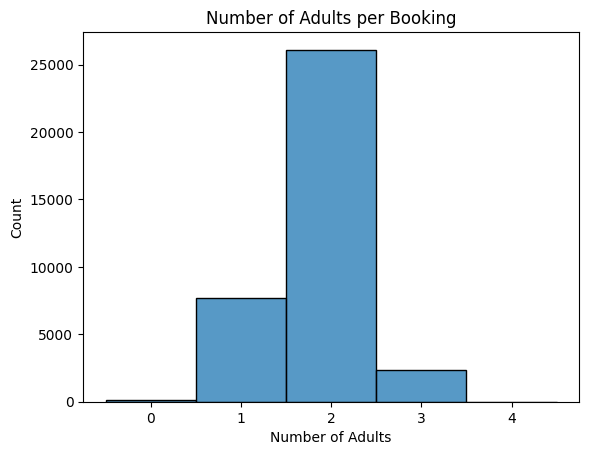

```python
# the number of adults per booking
sns.histplot(data1.no_of_adults, discrete=True)
plt.xlabel('Number of Adults')
plt.ylabel('Count')
plt.title('Number of Adults per Booking')
plt.show()
# we used discrete=True because you can't have fractional people
```

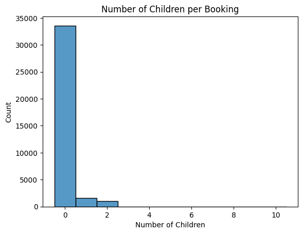

```python
# the number of children
sns.histplot(data1.no_of_children, discrete=True)
plt.xlabel('Number of Children')
plt.ylabel('Count')
plt.title('Number of Children per Booking')
plt.show()
```

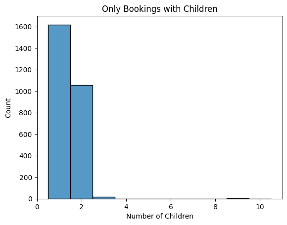

```python
# let's look again just at the people who don't have kids on their booking
data3=data1[data1.no_of_children!=0]
sns.histplot(data3.no_of_children, discrete=True)
plt.xlabel('Number of Children')
plt.ylabel('Count')
plt.title('Only Bookings with Children')
plt.show()
```

There's still an extremely sharp dropoff after 2 children. Let's also check for 3 or more kids.

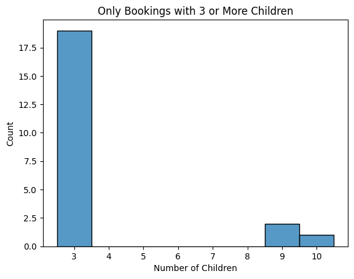

```python
# let's check bookings with 3 or more kids
data3=data1[data1.no_of_children>2]
sns.histplot(data3.no_of_children, discrete=True)
plt.xlabel('Number of Children')
plt.ylabel('Count')
plt.title('Only Bookings with 3 or More Children')
plt.show()
```

It looks like there were exactly three bookings with more than 3 children. One such booking had 10 children and two bookings had 9 children.

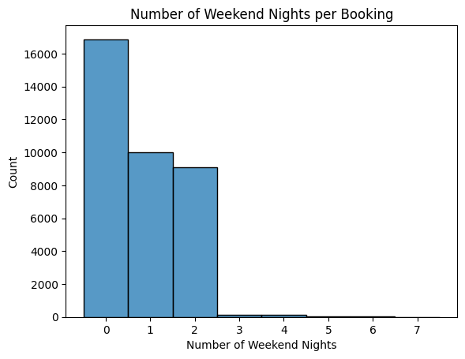

```python
# Let's check weekend nights stayed
sns.histplot(data1.no_of_weekend_nights, discrete=True)
plt.xlabel('Number of Weekend Nights')
plt.ylabel('Count')
plt.title('Number of Weekend Nights per Booking')
plt.show()
```

We can see that some guests stayed 3 or more weekend nights. This implies they stayed more than a week at a time.

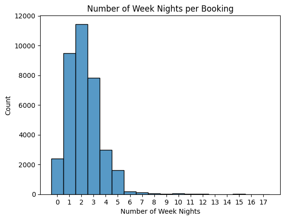

```python
# now weekday nights
sns.histplot(data1.no_of_week_nights, bins=range(int(data1.no_of_week_nights.min()), int(data1.no_of_week_nights.max()) + 1), discrete=True)
plt.xticks(range(int(data1.no_of_week_nights.min()), int(data1.no_of_week_nights.max()) + 1)) # I wanted the x-axis to not count by fractional numbers for better readability
plt.xlabel('Number of Week Nights')
plt.ylabel('Count')
plt.title('Number of Week Nights per Booking')
plt.show()
```

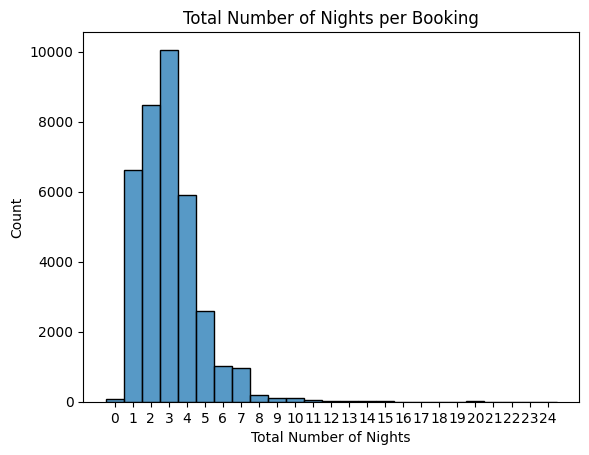

```python
# Now let's look at total weekday AND weekend nights for a given visit
data4=data1.copy()
data4['total_nights']=data4.no_of_weekend_nights+data4.no_of_week_nights
sns.histplot(data4.total_nights, bins=range(int(data4.total_nights.min()), int(data4.total_nights.max()) + 1), discrete=True)
plt.xticks(range(int(data4.total_nights.min()), int(data4.total_nights.max()) + 1))
plt.xlabel('Total Number of Nights')
plt.ylabel('Count')
plt.title('Total Number of Nights per Booking')
plt.show()
```

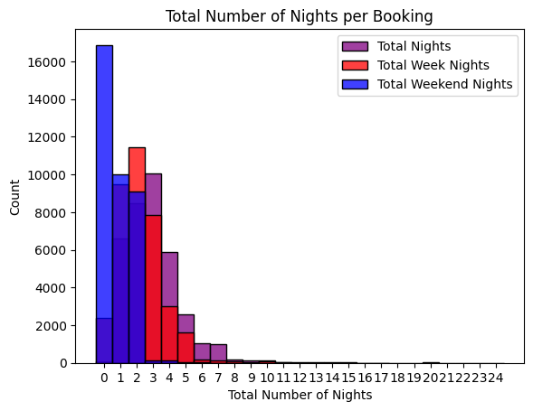

```python
# let's overlay the last three histograms
sns.histplot(data4.total_nights, bins=range(int(data4.total_nights.min()), int(data4.total_nights.max()) + 1), color='Purple', label='Total Nights', discrete=True)
sns.histplot(data4.no_of_week_nights, bins=range(int(data4.no_of_week_nights.min()), int(data4.no_of_week_nights.max()) + 1), color='Red', label='Total Week Nights', discrete=True)
sns.histplot(data4.no_of_weekend_nights, bins=range(int(data4.no_of_weekend_nights.min()), int(data4.no_of_weekend_nights.max()) + 1), color='Blue', label='Total Weekend Nights', discrete=True)
plt.xticks(range(int(data4.total_nights.min()), int(data4.total_nights.max()) + 1))
plt.xlabel('Total Number of Nights')
plt.ylabel('Count')
plt.title('Total Number of Nights per Booking')
plt.legend()
plt.show()
```

It was worth trying but the readability of this graph is somewhat low.

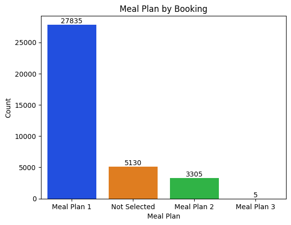

```python
meal_plan_counts = data4['type_of_meal_plan'].value_counts().reset_index()
meal_plan_counts.columns = ['type_of_meal_plan', 'count']

# a bar plot of the type of meal for each booking
ax = sns.barplot(x='type_of_meal_plan', y='count', data=meal_plan_counts, palette='bright')

# it took some time to figure out how to add labels to each bar
for p in ax.patches:
    ax.annotate(format(p.get_height(), '.0f'),
                (p.get_x() + p.get_width() / 2., p.get_height()),
                ha='center', va='center',
                xytext=(0, 5),
                textcoords='offset points')

plt.xlabel('Meal Plan')
plt.ylabel('Count')
plt.title('Meal Plan by Booking')
plt.show()
```

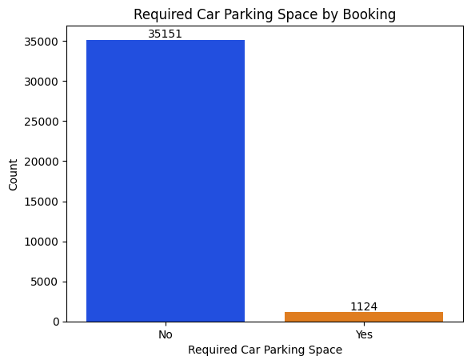

```python
# now a bar plot but for required_car_parking_soace
required_space_counts = data4['required_car_parking_space'].value_counts().reset_index()
required_space_counts.columns = ['required_car_parking_space', 'count']

ax = sns.barplot(x='required_car_parking_space', y='count', data=required_space_counts, palette='bright')

for p in ax.patches:
    ax.annotate(format(p.get_height(), '.0f'),
                (p.get_x() + p.get_width() / 2., p.get_height()),
                ha='center', va='center',
                xytext=(0, 5),
                textcoords='offset points')

ax.set_xticks([0, 1])  # Set x-ticks to 0 and 1
ax.set_xticklabels(['No', 'Yes'])  # Set x-tick labels to 'No' and 'Yes'

plt.xlabel('Required Car Parking Space')
plt.ylabel('Count')
plt.title('Required Car Parking Space by Booking')
plt.show()
```

Seems most customers did not explicitly require a parking space.

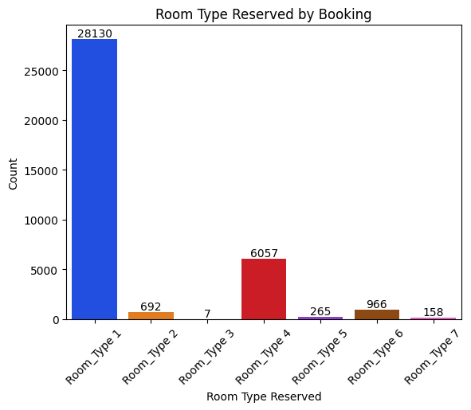

```python
# Bar plot of Room Type Reserved (we don't actually know what the room types are)
room_type_counts = data4['room_type_reserved'].value_counts().reset_index()
room_type_counts.columns = ['room_type_reserved', 'count']

# let's alphabatize the list so the room type reserved shows up in order
room_type_counts = room_type_counts.sort_values(by='room_type_reserved')

ax=sns.barplot(x='room_type_reserved', y='count', data=room_type_counts, palette='bright')

for p in ax.patches:
    ax.annotate(format(p.get_height(), '.0f'),
                (p.get_x() + p.get_width() / 2., p.get_height()),
                ha='center', va='center',
                xytext=(0, 5),
                textcoords='offset points')

plt.xlabel('Room Type Reserved')
plt.ylabel('Count')
plt.xticks(rotation=45)
plt.title('Room Type Reserved by Booking')
plt.show()
```

I don't know what type of room it is, but it seems that Room_Type1 is by far the most popular.

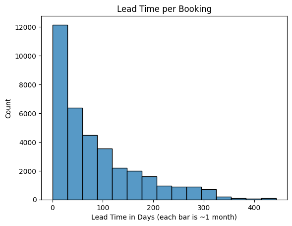

```python
# next is lead days and although it's discrete numbers, this particular category will have a large number of unique values
# therefor a histogram with bins is best
sns.histplot(data4.lead_time, binwidth=30)
plt.xlabel('Lead Time in Days (each bar is ~1 month)')
plt.ylabel('Count')
plt.title('Lead Time per Booking')
plt.show()
```

This makes sense overall. People are more likely to book in the few months leading up to the hotel stay. It seems that some people were booking over 400 days in advance with is noteworthy.

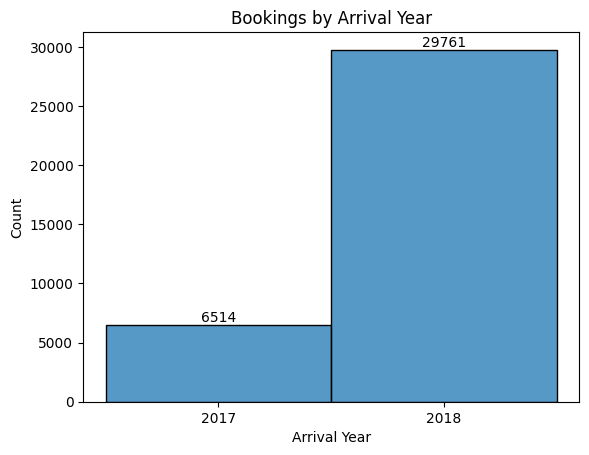

```python
# bookings by arrival year
ax=sns.histplot(data4.arrival_year, bins=2, discrete=True)

unique_years = sorted(data4['arrival_year'].unique())
ax.set_xticks(unique_years)  # this fixes trouble with the xtick labels
ax.set_xticklabels([str(year) for year in unique_years])

for p in ax.patches:
    ax.annotate(format(p.get_height(), '.0f'),
                (p.get_x() + p.get_width() / 2., p.get_height()),
                ha='center', va='center',
                xytext=(0, 5),
                textcoords='offset points')

plt.xlabel('Arrival Year')
plt.ylabel('Count')
plt.title('Bookings by Arrival Year')
plt.show()
```

There was either some reason that there were significantly fewer bookings in 2017 or more data was gathered in 2018. If data was only gathered from part of 2017, the information broken down by month will be weighted towards the months where data was gathered in 2017 and 2018. That being said, when I look at the breakdown by month, I will also do a second analysis broken down by month and year.

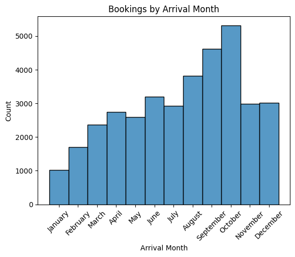

```python
# bookings by month
# i want the months to display on the chart, not the numerical representation of the months
month_names = {1: 'January', 2: 'February', 3: 'March', 4: 'April', 5: 'May', 6: 'June',
                7: 'July', 8: 'August', 9: 'September', 10: 'October', 11: 'November', 12: 'December'}

sns.histplot(data4['arrival_month'], discrete=True, bins=12)

plt.xlabel('Arrival Month')
plt.ylabel('Count')
plt.title('Bookings by Arrival Month')

# set xticks to the month names in calendar order
plt.xticks(ticks=list(month_names.keys()), labels=list(month_names.values()), rotation=45)

plt.show()
```

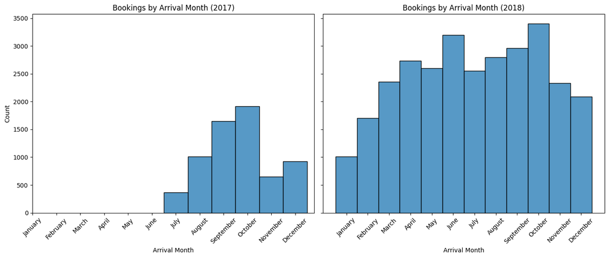

```python
# now broken up by year
month_names = {1: 'January', 2: 'February', 3: 'March', 4: 'April', 5: 'May', 6: 'June',
                7: 'July', 8: 'August', 9: 'September', 10: 'October', 11: 'November', 12: 'December'}

# Filter data for 2017 and 2018
data_2017 = data4[data4['arrival_year'] == 2017]
data_2018 = data4[data4['arrival_year'] == 2018]

# Create subplots
fig, axes = plt.subplots(1, 2, figsize=(14, 6), sharey=True)

# 2017
sns.histplot(data=data_2017, x='arrival_month', discrete=True, bins=12, ax=axes[0], multiple='stack')
axes[0].set_title('Bookings by Arrival Month (2017)')
axes[0].set_xlabel('Arrival Month')
axes[0].set_ylabel('Count')
axes[0].set_xticks(list(month_names.keys()))
axes[0].set_xticklabels(list(month_names.values()), rotation=45)

# 2018
sns.histplot(data=data_2018, x='arrival_month', discrete=True, bins=12, ax=axes[1], multiple='stack')
axes[1].set_title('Bookings by Arrival Month (2018)')
axes[1].set_xlabel('Arrival Month')
axes[1].set_ylabel('Count')
axes[1].set_xticks(list(month_names.keys()))
axes[1].set_xticklabels(list(month_names.values()), rotation=45)

plt.tight_layout()
plt.show()
```

This is exactly what I was worried about. It appears the data collection began part way through 2017. The previous graph that has all the bookings weighted by month is left skewed but that's only because we have two years worth of data entries for the second half of the calander year and only one years worth for the first half of the calander year. This shouldn't affect our decision tree but it does affect the appearance of the data broken down by month.

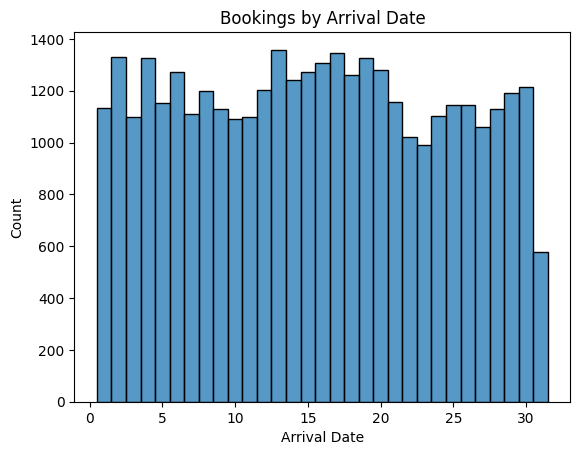

```python
# by day of the month
sns.histplot(data4.arrival_date, discrete=True)
plt.xlabel('Arrival Date')
plt.ylabel('Count')
plt.title('Bookings by Arrival Date')
plt.show()
```

This data appears exactly as we would expect. A generally uniform distribution with half as many values on the 31 as the other dates because half the months don't have a 31st day.

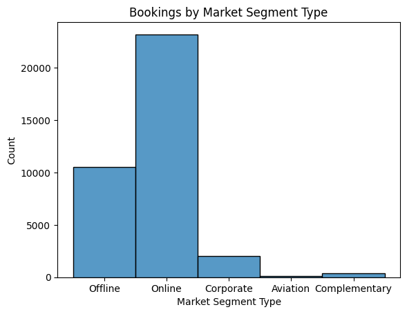

```python
# by market segment type
sns.histplot(data4.market_segment_type, discrete=True)
plt.xlabel('Market Segment Type')
plt.ylabel('Count')
plt.title('Bookings by Market Segment Type')
plt.show()
```

If I was working for a company on this project, I would ask for clarification about the meanings behind the market segment type designations in order to see if there is more insightful information that could be gleaned here. That being said, more than half the bookings were done online. Past that, nearly all the bookings fall into the "offline" or "online" categories with only a small fraction coming from the other three segments combined.

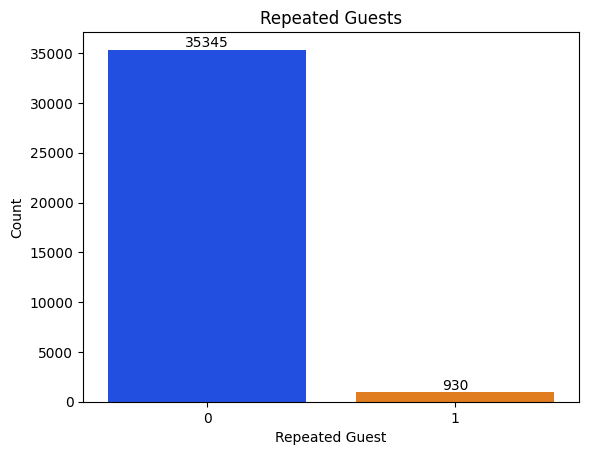

```python
# how many customers are repeat guests
repeated_guest_count=data4.repeated_guest.value_counts().reset_index()
repeated_guest_count.columns=['repeated_guest', 'count']

ax=sns.barplot(x='repeated_guest', y='count', data=repeated_guest_count, palette='bright')

for p in ax.patches:
    ax.annotate(format(p.get_height(), '.0f'),
                (p.get_x() + p.get_width() / 2., p.get_height()),
                ha='center', va='center',
                xytext=(0, 5),
                textcoords='offset points')

plt.xlabel('Repeated Guest')
plt.ylabel('Count')
plt.title('Repeated Guests')
plt.show()
```

```python
x=930/35345
print(x)
```

```
0.026312066770405998
```

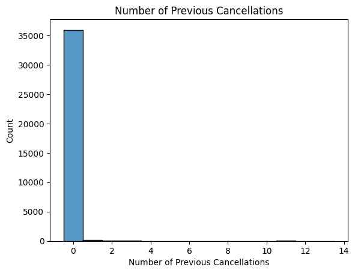

```python
# number of previous cancelations
sns.histplot(data4.no_of_previous_cancellations, discrete=True)
plt.xlabel('Number of Previous Cancellations')
plt.ylabel('Count')
plt.title('Number of Previous Cancellations')
plt.show()
```

We can see here that the majority of guests have not had a previous cancellation. Let's check only the cancellations more than zero.

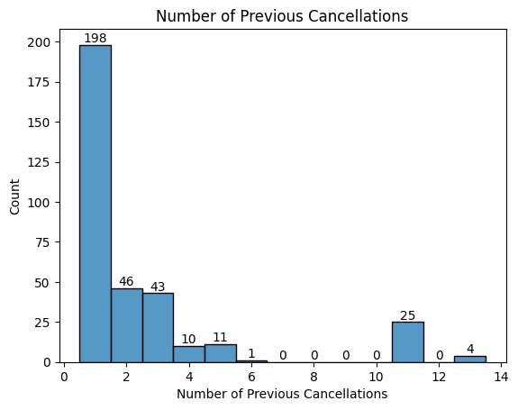

```python
# let's check only the cancellations more than zero
data5=data4[data4.no_of_previous_cancellations!=0]
ax = sns.histplot(data5.no_of_previous_cancellations, discrete=True)

for p in ax.patches:
    ax.annotate(format(p.get_height(), '.0f'),
                (p.get_x() + p.get_width() / 2., p.get_height()),
                ha='center', va='center',
                xytext=(0, 5),
                textcoords='offset points')

plt.xlabel('Number of Previous Cancellations')
plt.ylabel('Count')
plt.title('Number of Previous Cancellations')
plt.show()
```

There is nothing particularly noteworthy here except maybe that there are 25 guests who cancelled 11 times. This specific number of cancellations accounts for about half the total guests who have cancelled 4 or more times. It might be worth looking into why this is.

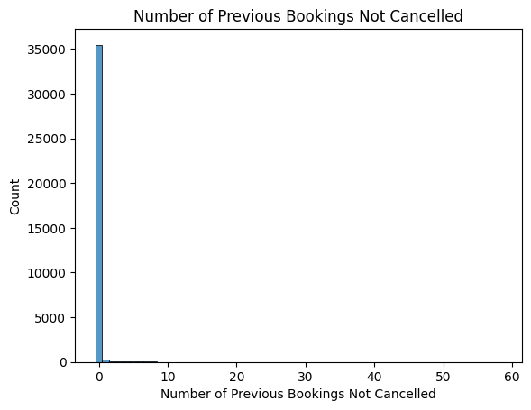

```python
# number of previous bookings not cancelled
sns.histplot(data4.no_of_previous_bookings_not_canceled, discrete=True)
plt.xlabel('Number of Previous Bookings Not Cancelled')
plt.ylabel('Count')
plt.title('Number of Previous Bookings Not Cancelled')
plt.show()
```

This is probably what we would expect to see out of most hotel guests. Most people do not stay in hotels extremely frequently. Nothing noteworthy here. Let's check the guests with greater than zero previous stays.

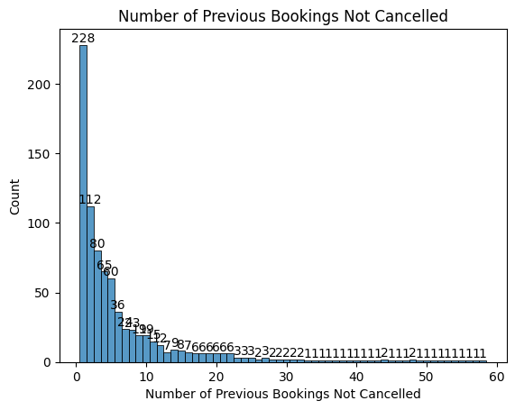

```python
# let's check the guests who stayed more than once
data6=data4[data4.no_of_previous_bookings_not_canceled!=0]
ax = sns.histplot(data6.no_of_previous_bookings_not_canceled, discrete=True)

for p in ax.patches:
    ax.annotate(format(p.get_height(), '.0f'),
                (p.get_x() + p.get_width() / 2., p.get_height()),
                ha='center', va='center',
                xytext=(0, 5),
                textcoords='offset points')

plt.xlabel('Number of Previous Bookings Not Cancelled')
plt.ylabel('Count')
plt.title('Number of Previous Bookings Not Cancelled')
plt.show()
```

Although this particular graph is not very readable, it is interesting to see that there is a comparitively small subset of hotel guests that have stayed 30, 40, or even 50 times in less than a year and a half.

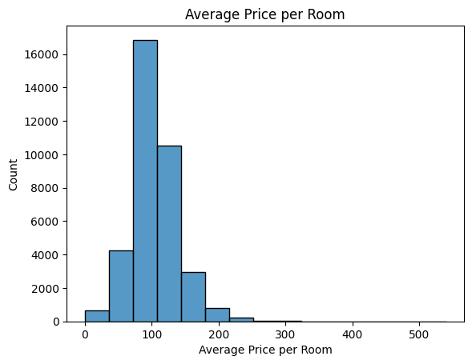

```python
# average price per room
sns.histplot(data4.avg_price_per_room, bins=15)
plt.xlabel('Average Price per Room')
plt.ylabel('Count')
plt.title('Average Price per Room')
plt.show()
```

The vast majority of rooms seem to cost between $80 and $180 roughly. It will be interesting to compare Price per Room and cancellations.

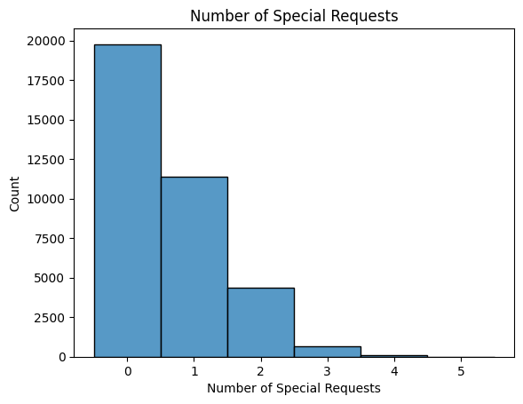

```python
# number of special requests
sns.histplot(data4.no_of_special_requests, discrete=True)
plt.xlabel('Number of Special Requests')
plt.ylabel('Count')
plt.title('Number of Special Requests')
plt.show()
```

This is interesting to me because I would have assumed that the '0' column would be much taller.

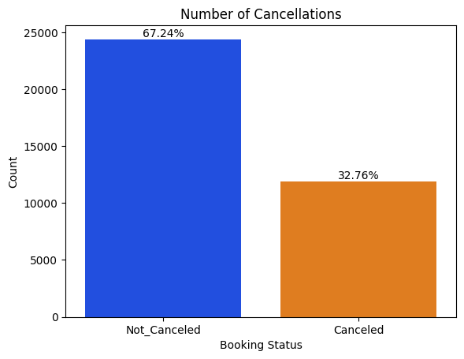

```python
# finally, cancellation status, the thing we're trying to predict
booking_status_count = data4.booking_status.value_counts().reset_index()
booking_status_count.columns = ['booking_status', 'count']

# calculate the percentage of each booking status
total_entries = booking_status_count['count'].sum()
booking_status_count['Percentage'] = (booking_status_count['count'] / total_entries) * 100

ax = sns.barplot(x='booking_status', y='count', data=booking_status_count, palette='bright')

for p in ax.patches:
    height = p.get_height()
    status_label = booking_status_count.iloc[int(p.get_x() + p.get_width() / 2)]['booking_status']
    percentage = booking_status_count[booking_status_count['booking_status'] == status_label]['Percentage'].values[0]
    ax.annotate(f'{percentage:.2f}%',
                (p.get_x() + p.get_width() / 2., height),
                ha='center', va='center',
                xytext=(0, 5),
                textcoords='offset points')

plt.xlabel('Booking Status')
plt.ylabel('Count')
plt.title('Number of Cancellations')
plt.show()
```

I can see why a company would want to be able to predict cancellations, if 1/3 of all bookings get cancelled, then that wastes a lot of potential revenue.

### Leading Questoins

**Leading Questions**:

1. What are the busiest months in the hotel?
2. Which market segment do most of the guests come from?
3. Hotel rates are dynamic and change according to demand and customer demographics. What are the differences in room prices in different market segments?
4. What percentage of bookings are canceled?
5. Repeating guests are the guests who stay in the hotel often and are important to brand equity. What percentage of repeating guests cancel?
6. Many guests have special requirements when booking a hotel room. Do these requirements affect booking cancellation?

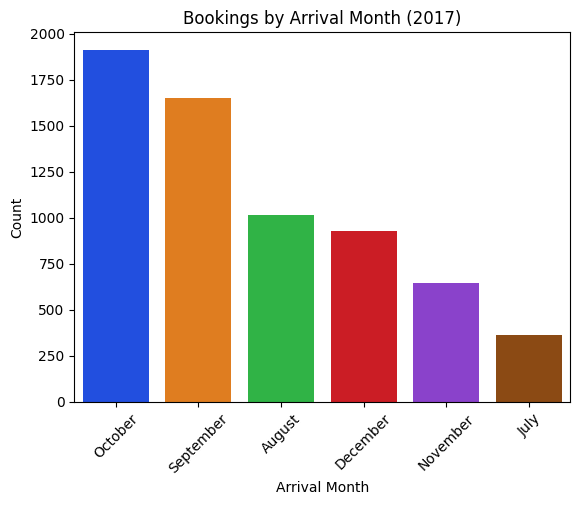

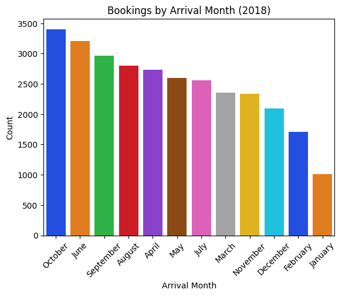

```python
# question 1
# What are the busiest months in the hotel
month_names = {1: 'January', 2: 'February', 3: 'March', 4: 'April', 5: 'May', 6: 'June',
                7: 'July', 8: 'August', 9: 'September', 10: 'October', 11: 'November', 12: 'December'}

# Filter data for 2017
data_2017 = data4[data4['arrival_year'] == 2017]

# Calculate monthly counts for 2017
monthly_counts_2017 = data_2017['arrival_month'].value_counts().sort_index()
monthly_counts_2017 = monthly_counts_2017.rename_axis('arrival_month').reset_index(name='count')
monthly_counts_2017 = monthly_counts_2017.sort_values(by='count', ascending=False)
monthly_counts_2017['arrival_month'] = pd.Categorical(monthly_counts_2017['arrival_month'], categories=monthly_counts_2017['arrival_month'], ordered=True)

# Create the plot
sns.barplot(x='arrival_month', y='count', data=monthly_counts_2017, palette='bright')
plt.title('Bookings by Arrival Month (2017)')
plt.xlabel('Arrival Month')
plt.ylabel('Count')
plt.xticks(ticks=range(len(monthly_counts_2017['arrival_month'])), labels=[month_names[m] for m in monthly_counts_2017['arrival_month']], rotation=45)
plt.show()

# Filter data for 2018
data_2018 = data4[data4['arrival_year'] == 2018]

# Calculate monthly counts for 2018
monthly_counts_2018 = data_2018['arrival_month'].value_counts().sort_index()
monthly_counts_2018 = monthly_counts_2018.rename_axis('arrival_month').reset_index(name='count')
monthly_counts_2018 = monthly_counts_2018.sort_values(by='count', ascending=False)
monthly_counts_2018['arrival_month'] = pd.Categorical(monthly_counts_2018['arrival_month'], categories=monthly_counts_2018['arrival_month'], ordered=True)

# Create the plot
sns.barplot(x='arrival_month', y='count', data=monthly_counts_2018, palette='bright')
plt.title('Bookings by Arrival Month (2018)')
plt.xlabel('Arrival Month')
plt.ylabel('Count')
plt.xticks(ticks=range(len(monthly_counts_2018['arrival_month'])), labels=[month_names[m] for m in monthly_counts_2018['arrival_month']], rotation=45)
plt.show()
```

**Question 1**

- October, June, and September were most popular in 2018
- October, September, and August were most popular in 2017
- Less data was gathered in 2017, even accounting for only gathering data part of the year. The highest booking month in 2017 was comparable to the second lowest booking month in 2018.

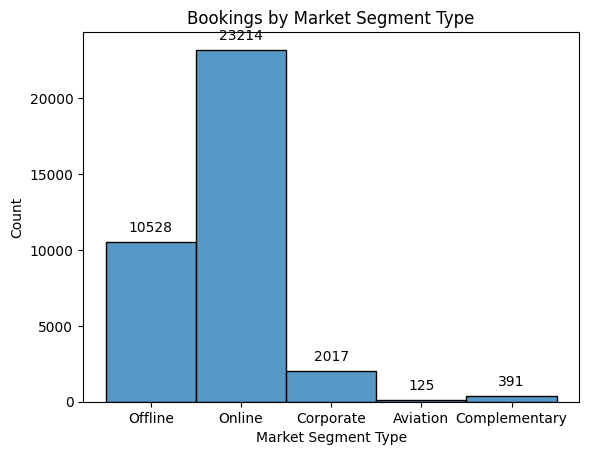

```python
# question 2
# Which market segment do most of the guests come from?
ax = sns.histplot(data4.market_segment_type, discrete=True)

for p in ax.patches:
    ax.annotate(format(p.get_height(), '.0f'),
                (p.get_x() + p.get_width() / 2., p.get_height()),
                ha='center', va='bottom',
                xytext=(0, 5),
                textcoords='offset points')

plt.xlabel('Market Segment Type')
plt.ylabel('Count')
plt.title('Bookings by Market Segment Type')
plt.show()
# this plot was already done in Univraite analysis above
```

```python
x=23214/36275
print(x)
```

```
0.6399448656099241
```

**Question 2**

- 64% of the bookings were the 'Online' segment type

```python
# question 3
# Hotel rates are dynamic and change according to demand and customer demographics.
# What are the differences in room prices in different market segments?
mean_price_by_segment = data4.groupby('market_segment_type')['avg_price_per_room'].mean().reset_index()

# Round to 2 decimal places for readability
mean_price_by_segment['avg_price_per_room'] = mean_price_by_segment['avg_price_per_room'].apply(lambda x: f'{x:.2f}')
print(mean_price_by_segment)
```

```
  market_segment_type avg_price_per_room
0            Aviation             100.70
1       Complementary               3.14
2           Corporate              82.91
3             Offline              91.63
4              Online             112.26
```

**Question 3**

- We can see that ordering online, which we already know to be the most popular method, is also the most expensive method.
- It can't be said for certain from the data, but I imagine that because corporate entities and aviation industries do so much business with hotels, they get discount incentives

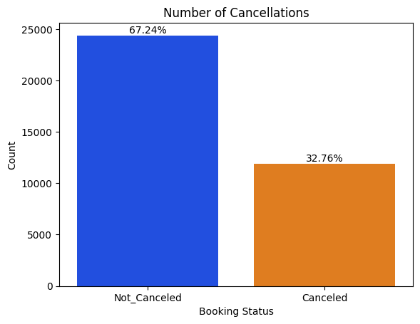

```python
# question 4
# What percentage of bookings are canceled?
# this is convenient because I already had this answer before I got to this question
booking_status_count = data4.booking_status.value_counts().reset_index()
booking_status_count.columns = ['booking_status', 'count']

# calculate the percentage of each booking status
total_entries = booking_status_count['count'].sum()
booking_status_count['Percentage'] = (booking_status_count['count'] / total_entries) * 100

ax = sns.barplot(x='booking_status', y='count', data=booking_status_count, palette='bright')

for p in ax.patches:
    height = p.get_height()
    status_label = booking_status_count.iloc[int(p.get_x() + p.get_width() / 2)]['booking_status']
    percentage = booking_status_count[booking_status_count['booking_status'] == status_label]['Percentage'].values[0]
    ax.annotate(f'{percentage:.2f}%',
                (p.get_x() + p.get_width() / 2., height),
                ha='center', va='center',
                xytext=(0, 5),
                textcoords='offset points')

plt.xlabel('Booking Status')
plt.ylabel('Count')
plt.title('Number of Cancellations')
plt.show()
```

**Question 4**

- We can see that 32.76% of bookings are cancelled.

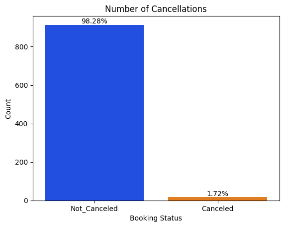

```python
# question 5
# Repeating guests are the guests who stay in the hotel often and are important to brand equity.
# What percentage of repeating guests cancel?
data6=data4[data4.repeated_guest!=0]
booking_status_count = data6.booking_status.value_counts().reset_index()
booking_status_count.columns = ['booking_status', 'count']

# calculate the percentage of each booking status
total_entries = booking_status_count['count'].sum()
booking_status_count['Percentage'] = (booking_status_count['count'] / total_entries) * 100

ax = sns.barplot(x='booking_status', y='count', data=booking_status_count, palette='bright')

for p in ax.patches:
    height = p.get_height()
    status_label = booking_status_count.iloc[int(p.get_x() + p.get_width() / 2)]['booking_status']
    percentage = booking_status_count[booking_status_count['booking_status'] == status_label]['Percentage'].values[0]
    ax.annotate(f'{percentage:.2f}%',
                (p.get_x() + p.get_width() / 2., height),
                ha='center', va='center',
                xytext=(0, 5),
                textcoords='offset points')

plt.xlabel('Booking Status')
plt.ylabel('Count')
plt.title('Number of Cancellations')
plt.show()
```

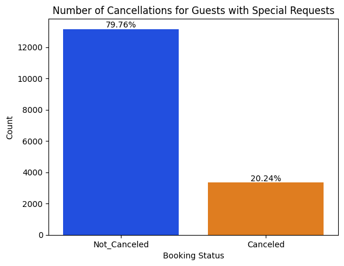

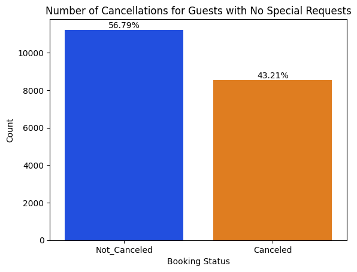

```python
# question 6
# Many guests have special requirements when booking a hotel room. Do these requirements affect booking cancellation?

# first lets look at 1 or more special requests
data7=data4[data4.no_of_special_requests!=0]
booking_status_count = data7.booking_status.value_counts().reset_index()
booking_status_count.columns = ['booking_status', 'count']

total_entries = booking_status_count['count'].sum()
booking_status_count['Percentage'] = (booking_status_count['count'] / total_entries) * 100

ax = sns.barplot(x='booking_status', y='count', data=booking_status_count, palette='bright')

for p in ax.patches:
    height = p.get_height()
    status_label = booking_status_count.iloc[int(p.get_x() + p.get_width() / 2)]['booking_status']
    percentage = booking_status_count[booking_status_count['booking_status'] == status_label]['Percentage'].values[0]
    ax.annotate(f'{percentage:.2f}%',
                (p.get_x() + p.get_width() / 2., height),
                ha='center', va='center',
                xytext=(0, 5),
                textcoords='offset points')

plt.xlabel('Booking Status')
plt.ylabel('Count')
plt.title('Number of Cancellations for Guests with Special Requests')
plt.show()

# second, let's look at cancellations for guests who made no special requests
data8=data4[data4.no_of_special_requests==0]
booking_status_count = data8.booking_status.value_counts().reset_index()
booking_status_count.columns = ['booking_status', 'count']

total_entries = booking_status_count['count'].sum()
booking_status_count['Percentage'] = (booking_status_count['count'] / total_entries) * 100

ax = sns.barplot(x='booking_status', y='count', data=booking_status_count, palette='bright')

for p in ax.patches:
    height = p.get_height()
    status_label = booking_status_count.iloc[int(p.get_x() + p.get_width() / 2)]['booking_status']
    percentage = booking_status_count[booking_status_count['booking_status'] == status_label]['Percentage'].values[0]
    ax.annotate(f'{percentage:.2f}%',
                (p.get_x() + p.get_width() / 2., height),
                ha='center', va='center',
                xytext=(0, 5),
                textcoords='offset points')

plt.xlabel('Booking Status')
plt.ylabel('Count')
plt.title('Number of Cancellations for Guests with No Special Requests')
plt.show()
```

**Question 6**

- This is really interesting. Guests who made no special requests are about twice as likely to cancel as guests who had special requests.